# html

## Load Data

```python
import pandas as pd
import numpy as np

UserActivity = pd.read_csv('https://storage.googleapis.com/datalynn-datasets/interview-challenge/technology/TikTok_Ads/UserActivity.csv')
AdCampaigns = pd.read_csv('https://storage.googleapis.com/datalynn-datasets/interview-challenge/technology/TikTok_Ads/AdCampaigns.csv')
UserPatterns = pd.read_csv('https://storage.googleapis.com/datalynn-datasets/interview-challenge/technology/TikTok_Ads/UserPatterns.csv')
```

### Question 1

**Scenario:** A hypothesis has been posited by the marketing team suggesting that video ads drive more user interactions (likes, shares, comments) and have better performance than other ad types. Using the `UserActivity` table, verify this hypothesis.

**Problem Solving Ideas and Tips:**

- First, filter out interactions where `InteractionType` is 'None' since that indicates no interaction.
- Then, group the data by `AdType` to calculate the total interactions for each ad type.
- Check if video ads have more interactions than other ad types.
- For performance, a common metric is Engagement per Unit of Investment. You can utilize the following formula: Engagement per Unit of Investment = Gain from Investment / Cost of Investment.
  - In our scenario, interactions can be seen as "gain" and budget can be viewed as "cost". Although it's a simplistic view, it will provide a comparative metric.
- Join the `UserActivity` table with `AdCampaigns` table to get the `Budget` and `AdType` for each `VideoId`.

```python
import sqlite3

# Convert pandas dataframes to SQL tables using sqlite3
conn = sqlite3.connect(':memory:')
UserActivity.to_sql('UserActivity', conn, index=False)
AdCampaigns.to_sql('AdCampaigns', conn, index=False)

# SQL to verify the hypothesis and calculate ROI for video ad campaigns
query = """
SELECT
    UA.AdType,
    COUNT(DISTINCT UA.VideoId) as TotalInteractions,
    AC.Budget,
    CAST(COUNT(DISTINCT UA.VideoId) as FLOAT) / AC.Budget as EngagementPerInvestment
FROM
    UserActivity UA
JOIN
    AdCampaigns AC
ON
    UA.AdType = AC.AdType
WHERE
    UA.InteractionType != 'None'
GROUP BY
    UA.AdType
ORDER BY
    EngagementPerInvestment DESC;
"""

result = pd.read_sql_query(query, conn)
result.head()
```

|  | AdType | TotalInteractions | Budget | EngagementPerInvestment |
| --- | --- | --- | --- | --- |
| 0 | Video | 12636 | 5341.054213 | 2.365825 |
| 1 | Image | 10985 | 5081.703357 | 2.161677 |
| 2 | Carousel | 3555 | 5012.323617 | 0.709252 |

### Question 2

**Scenario:** As the digital advertising space evolves, so does the risk of fraudulent activities. Leveraging the `UserActivity` and `UserPatterns` tables, propose a machine learning model to detect potential anomalies like bots or non-human interactions that could skew ad performance metrics. Specify which features you'd extract, the model's training process, validation strategy, and its potential implications for ad campaign assessments.

**Problem Solving Ideas and Tips:**

#### 1. Feature Extraction:

- **Video Interactions:** Count of unique videos a user has interacted with.
- **Clicks:** Count of clicks a user has made on videos.
- **AvgTimeBetweenInteractions:** Average time between user interactions.
- **OffPeakInteractions:** Number of interactions a user has made during off-peak hours.

#### 2. Model Selection:

For unsupervised anomaly detection, we will utilize the **Isolation Forest** algorithm. This method is based on the principle that anomalies are observations that are rare and different and should be easier to "isolate" compared to regular observations.

#### 3. Implications for Ad Campaign Assessments:

- **Enhanced Accuracy:** By detecting and removing bot interactions, metrics such as engagement rates, click-through rates, and conversion rates will be more accurate, leading to better ROI estimations.
- **Budget Efficiency:** Advertisers will get more value for their spend, as they're targeting genuine users and not wasting money on bots.
- **Trustworthiness:** By ensuring metrics aren't skewed by fraudulent activities, advertisers can trust the platform more, leading to increased investments

```python
import sqlite3
import pandas as pd
from sklearn.preprocessing import StandardScaler
from sklearn.ensemble import IsolationForest
import matplotlib.pyplot as plt
import seaborn as sns

# Convert pandas dataframe to SQL table using sqlite3
conn = sqlite3.connect(':memory:')
UserActivity.to_sql('UserActivity', conn, index=False)
UserPatterns.to_sql('UserPatterns', conn, index=False)

# SQL query to generate AvgTimeBetweenInteractions and OffPeakInteractions
query = """
WITH InteractionsWithLag AS (
    SELECT
        UserId,
        InteractionTimestamp,
        LAG(InteractionTimestamp) OVER (PARTITION BY UserId ORDER BY InteractionTimestamp) as PrevInteractionTime
    FROM
        UserActivity
),

TimeBetweenInteractions AS (
    SELECT
        UserId,
        JULIANDAY(InteractionTimestamp) - JULIANDAY(PrevInteractionTime) as TimeDifference
    FROM
        InteractionsWithLag
    WHERE
        PrevInteractionTime IS NOT NULL
)

SELECT
    T.UserId,
    AVG(T.TimeDifference) as AvgTimeBetweenInteractions,
    SUM(CASE WHEN strftime('%H', UA.InteractionTimestamp) BETWEEN '00' AND '06' THEN 1 ELSE 0 END) as OffPeakInteractions
FROM
    TimeBetweenInteractions T
JOIN
    UserActivity UA
ON
    T.UserId = UA.UserId
GROUP BY
    T.UserId
"""

features = pd.read_sql(query, conn)

# Extracting features from UserActivity and UserPatterns
query = """
SELECT
    UA.UserId,
    COUNT(DISTINCT UA.VideoId) as VideoInteractions,
    SUM(CASE WHEN UA.InteractionType = 'Click' THEN 1 ELSE 0 END) as Clicks
FROM
    UserActivity UA
JOIN
    UserPatterns UP
ON
    UA.UserId = UP.UserId
GROUP BY
    UA.UserId
"""

features2 = pd.read_sql(query, conn)
conn.close()
```

```python
data = pd.merge(features,features2,on='UserId')
data.head()
```

|  | UserId | AvgTimeBetweenInteractions | OffPeakInteractions | VideoInteractions | Clicks |
| --- | --- | --- | --- | --- | --- |
| 0 | U00001 | 5.095833 | 4 | 5 | 0 |
| 1 | U00002 | 4.079398 | 18 | 7 | 0 |
| 2 | U00003 | 7.914062 | 4 | 5 | 0 |
| 3 | U00004 | 2.455456 | 21 | 8 | 0 |
| 4 | U00005 | 10.719907 | 3 | 4 | 0 |

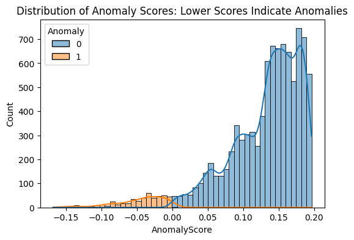

```python
data = data.drop('UserId',axis=1)

# Scaling the features
scaler = StandardScaler()
scaled_data = scaler.fit_transform(data)

# Using Isolation Forest for Anomaly Detection
clf = IsolationForest(contamination=0.05)  # Assuming 5% of the data is anomalous
clf.fit(scaled_data)

# Getting anomaly scores
data['AnomalyScore'] = clf.decision_function(scaled_data)
data['Anomaly'] = clf.predict(scaled_data)
data['Anomaly'] = data['Anomaly'].map({1: 0, -1: 1})

# Visualization
plt.figure(figsize=(6,4))
sns.histplot(data=data, x='AnomalyScore', hue='Anomaly', bins=50, kde=True)
plt.title('Distribution of Anomaly Scores: Lower Scores Indicate Anomalies')
plt.show()
```

**Analysis and Results:**

The code first extracts relevant features from the database. The features are then scaled, which is a necessary step before training Isolation Forest.

The model is then trained on the scaled data, and each instance is assigned an anomaly score using the `decision_function`. Higher scores indicate normal instances, while lower scores hint at anomalies. We've also labeled the data as normal (0) or anomaly (1) based on the predictions from the Isolation Forest model.

The visualization provides insights into the distribution of anomaly scores. This can be used to adjust the threshold if needed.

By identifying anomalies, TikTok can take further steps to analyze and potentially remove such activities to ensure more accurate ad campaign assessments.

### Question 3

**Scenario:** Now that we have a good fraud model, how can we decrease such activities on the platform? Furthermore, how should we adjust the ad campaign assessment metrics? Provide both the original and adjusted definitions of the metrics you choose.

**Problem Solving Ideas and Tips:**

1. **Detection and Prevention**:
   - Using the fraud model, classify users' interactions as genuine or fraudulent.
   - Take proactive actions on interactions flagged as fraudulent. This could be in the form of warnings, temporary suspensions, or even permanent bans for repeated offenses.
2. **Feedback Loop**:
   - How to make sure the model is reliable over time?
3. **Ad Campaign Metrics**:
   - Typically, metrics like Click Through Rate (CTR), Conversion Rate, and Cost Per Click (CPC) are used to assess ad campaigns.
   - Think about how fraud click would impact the metrics

#### Solution:

1. **Decreasing Fraudulent Activities**:
   - **Automated Monitoring**: Set up automated systems that monitor user activity in real-time and flag suspicious activities using the fraud model.
   - **User Verification**: Implement more robust user verification processes to ensure that users are genuine and not bots. This could involve phone verification, CAPTCHAs, or even biometric verifications.
   - **Enhanced Reporting**: Allow users and advertisers to report suspicious activity. These reports can then be used to refine the fraud model and take action against malicious users.
2. **Feedback Loop**:
   - Periodically retrain the fraud model using the latest data to account for evolving tactics used by fraudsters.
   - Incorporate feedback from users and advertisers to refine the model.
3. **Adjusting Ad Campaign Metrics**:
   - **Click Through Rate (CTR)**:
     - **Original**: Total Clicks / Total Impressions
     - **Adjusted**: Total Genuine Clicks (non-fraudulent as per the model) / Total Genuine Impressions (impressions that led to genuine interactions)
   - **Conversion Rate**:
     - **Original**: Total Conversions / Total Clicks
     - **Adjusted**: Total Genuine Conversions (non-fraudulent as per the model) / Total Genuine Clicks
   - **Cost Per Click (CPC)**:
     - **Original**: Total Cost / Total Clicks
     - **Adjusted**: Total Cost / Total Genuine Clicks

By implementing the adjusted metrics, TikTok can provide advertisers with more accurate data regarding their campaigns' performance, excluding the interactions flagged as fraudulent. This will lead to a more transparent and trustworthy advertising ecosystem on the platform.

### Question 4

**Scenario:** Recently, an advertiser collaborated with TikTok and initiated a hashtag challenge. Please devise a methodology to assess the challenge's effectiveness. How you'd distinguish the influence of the hashtag challenge from organic growth or other factors?

**Problem Solving Ideas and Tips:**

1. **Causal Inference**:
   - Is online experiment good enough? Think about the potential limitations of online experiments in this context.
   - What measures could help complementing the experiment itself?

#### Solution:

1. **Design a Controlled Experiment**:
   - **Treatment Group**: Users who are exposed to the hashtag challenge.
   - **Control Group**: Users who aren't exposed to the hashtag challenge.

You may easily think of the common metrics used at social media platform related to engagement, views, shares. However, the experiment is set up so that users in the control group are not able to see the hashtag challenge of the advertiser. Therefore, we should seek another way to evaluate the effectiveness of the treatment. This is where survey questionnaire comes into place.

By sending out survey to both treatment and control group, we can analyze the difference in two groups' perception of the brand and its products.

2. **Survey Design**:
   - **Awareness**: Ask respondents if they recall seeing the hashtag challenge and if they remember which brand was associated with it. (check if network effect exists, i.e., users in control group know about the treatment somewhere else)
   - **Engagement**: Gauge if they participated in the challenge, shared it, or engaged in any form.
   - **Brand Perception**: Ask questions like:
     - When was the last time they see the brand's advertisement in any form?
     - Are they more likely to purchase products from the brand?
     - How would they rate their overall sentiment about the brand post the hashtag challenge?
3. **Survey Implementation**:
   - **Timing**: Send out the survey soon after the hashtag challenge ends to ensure that it is fresh in the minds of the respondents.
   - **Multi-Channel**: Use various channels like in-app notifications, email, or even SMS to increase the survey response rate.
4. **Potential Limitations of Surveys**:
   - **Recall Bias**: Respondents might not remember the hashtag challenge or might misattribute it to a different brand.
   - **Response Bias**: People who have strong opinions (either positive or negative) might be more likely to respond, skewing results.

In conclusion, a well-structured survey, focusing primarily on the brand associated with the hashtag challenge, can offer valuable insights into the impact of the campaign. This data can then guide both TikTok and advertisers on the efficacy of such campaigns and how they can be optimized in the future.